# Lecture 20: Alternative forms

Data Analysis for Psychology in R 1

Tom Booth

Click for slides

## Today

- Briefly consider different forms of correlation and calculation in R

## Learning objectives

- Understand when to use different forms of correlation.
- Be able to run correct forms of correlation in R.

## Types of correlation

| X | Y | Correlation Type |
| --- | --- | --- |
| Continuous | Continuous | Pearson |
| Continuous | Categorical | Polyserial |
| Continuous | Binary | Biserial |
| Categorical | Categorical | Polychoric |
| Binary | Binary | Tetrachoric |
| Rank | Rank | Spearman |
| Nominal | Nominal | Chi-square |

## Spearman correlation

- Spearman’s $\rho$ (or rank-order correlation) is a *non-parametric* estimate of the association between two variables.
  - As name suggests, it uses data on the rank-ordering of X,Y responses for each individual.
- When would we choose to use the Spearman correlation?
  - If our data are naturally ranked data (e.g. imaging an experiment where the task is to rank foods and drinks in terms of preference).
  - If the data are non-normal or skewed.
  - If the data shows evidence of non-linearity.
- Spearman’s is not testing for linear relations, it is testing for increasing monotonic relationship.
  - Huh?

## Linear vs. monotonic

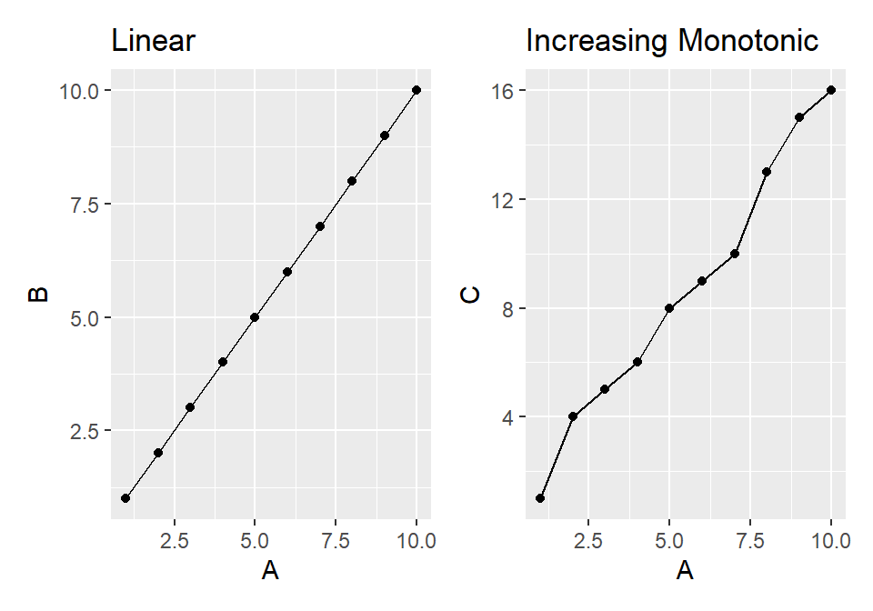

## Steps in Spearman’s

$$\rho = 1 - \frac{6\Sigma{d^2_i}}{n(n^2-1)}$$

## Quick example

```r
rank <- tibble(
  ID = paste("ID", 1:6, sep = ""),
  RT =c(.264, .311, .265, .291, .350, .500),
  Caff = c(210,280,150,90,200,450)
)
rank
# A tibble: 6 x 3
  ID       RT  Caff
  <chr> <dbl> <dbl>
1 ID1   0.264   210
2 ID2   0.311   280
3 ID3   0.265   150
4 ID4   0.291    90
5 ID5   0.35    200
6 ID6   0.5     450
```

## Calculation

```r
rank_calc <- rank %>%
  mutate(
    RT_rank = rank(RT),
    Caff_rank = rank(Caff),
    di = RT_rank - Caff_rank,
    di2 = di^2
  )
rank_calc
# A tibble: 6 x 7
  ID       RT  Caff RT_rank Caff_rank    di   di2
  <chr> <dbl> <dbl>   <dbl>     <dbl> <dbl> <dbl>
1 ID1   0.264   210       1         4    -3     9
2 ID2   0.311   280       4         5    -1     1
3 ID3   0.265   150       2         2     0     0
4 ID4   0.291    90       3         1     2     4
5 ID5   0.35    200       5         3     2     4
6 ID6   0.5     450       6         6     0     0
```

```r
rank_calc
# A tibble: 6 x 7
  ID       RT  Caff RT_rank Caff_rank    di   di2
  <chr> <dbl> <dbl>   <dbl>     <dbl> <dbl> <dbl>
1 ID1   0.264   210       1         4    -3     9
2 ID2   0.311   280       4         5    -1     1
3 ID3   0.265   150       2         2     0     0
4 ID4   0.291    90       3         1     2     4
5 ID5   0.35    200       5         3     2     4
6 ID6   0.5     450       6         6     0     0
```

$$\rho = 1 - \frac{6\Sigma{d^2_i}}{n(n^2-1)} = 1 - \frac{6*18}{6(6^2-1)} = 1 - \frac{108}{210} = 1 - 0.514 = 0.486$$

## In R

```r
cor(rank$RT, rank$Caff, method = "spearman")
[1] 0.4857143
```

## Other forms

- General principle (simplified a little) of the other forms of correlation is roughly the same.
- We assume that the categorical variable is a crude measurement of an underlying normal variable.
- Aiming to provide an estimate of the association between these underlying variables.

## Underlying continuous variable

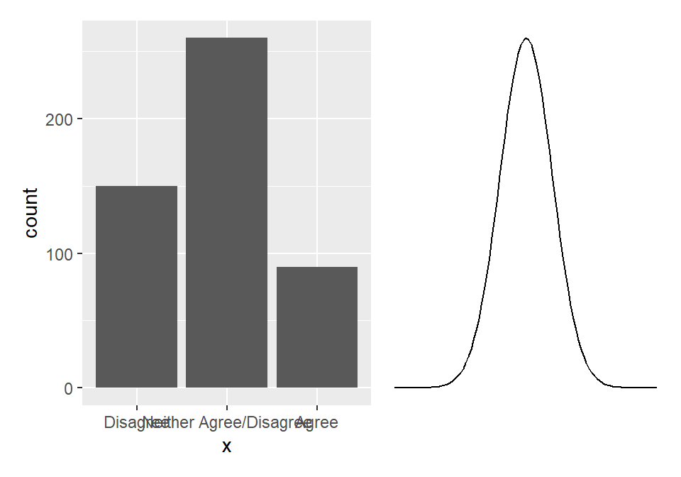

- Estimating correlation is straight forward.
- All we need to do is make sure R knows the type of data we have, then use `hetcor`

```r
pers_items <- bfi[,c(1:5)]
pers_items <- pers_items %>%
  mutate(
    A1 = as_factor(A1)
  )
pers_cors <- hetcor(pers_items)
```

```r
pers_cors$correlations
           A1         A2         A3         A4         A5
A1  1.0000000 -0.3679011 -0.2924884 -0.1639639 -0.2072343
A2 -0.3679011  1.0000000  0.4867503  0.3352432  0.3877875
A3 -0.2924884  0.4867503  1.0000000  0.3621720  0.5051762
A4 -0.1639639  0.3352432  0.3621720  1.0000000  0.3067003
A5 -0.2072343  0.3877875  0.5051762  0.3067003  1.0000000
```

```r
pers_cors$type
     [,1]         [,2]         [,3]         [,4]         [,5]
[1,] ""           "Polyserial" "Polyserial" "Polyserial" "Polyserial"
[2,] "Polyserial" ""           "Pearson"    "Pearson"    "Pearson"
[3,] "Polyserial" "Pearson"    ""           "Pearson"    "Pearson"
[4,] "Polyserial" "Pearson"    "Pearson"    ""           "Pearson"
[5,] "Polyserial" "Pearson"    "Pearson"    "Pearson"    ""
```

## Tasks for this week…

- Keep safe and healthy.